# Estudis d'Informàtica, Multimedia i Telecomunicacions

# Mineria de dades: PRA1 - Selecció i preparació d’un joc de dades

Autor: Arnau Garcia Rodríguez

Novembre 2023

# 1 Context i objectius

Imaginem que formem part del ministeri d’educació d’un país i volem saber quines condicions afavoreixen que els nostres alumnes de secundària tinguin millors qualificacions. D’aquesta forma, podrem dur a terme mesures per afavorir aquestes condicions i resoldre aquelles que són un impediment.

Obtindrem aquest coneixement i aplicarem models supervisats i no supervisats.

D’altra banda, mitjançant models no supervisats, classificarem les instàncies a partir de la similitud de les seves característiques.

# 2 Joc de dades

Utilitzarem un joc de dades anomenat **Student Performance**, que conté informació dels resultats obtinguts en la matèria de llengua portuguesa pels estudiants de dos instituts Portuguesos l’any 2008. Inclou característiques socials, demogràfiques, resultats i escolars.

S’ha obtingut el joc de dades mitjanánt la plataforma UCI Machine Learning.

# 3 Anàlisi exploratòria

El primer pas és importar el conjunt de dades i visualitzar el nombre d’instàncies i quin tipus d’atributs tenim disponibles.

```r
path = 'student-por.csv'
studentsData <- read.csv(path, row.names=NULL)
```

```r
structure = str(studentsData)
```

```
## 'data.frame':    649 obs. of  33 variables:
##  $ school    : chr  "GP" "GP" "GP" "GP" ...
##  $ sex       : chr  "F" "F" "F" "F" ...
##  $ age       : int  18 17 15 15 16 16 16 17 15 15 ...
##  $ address   : chr  "U" "U" "U" "U" ...
##  $ famsize   : chr  "GT3" "GT3" "LE3" "GT3" ...
##  $ Pstatus   : chr  "A" "T" "T" "T" ...
##  $ Medu      : int  4 1 1 4 3 4 2 4 3 3 ...
##  $ Fedu      : int  4 1 1 2 3 3 2 4 2 4 ...
##  $ Mjob      : chr  "at_home" "at_home" "at_home" "health" ...
##  $ Fjob      : chr  "teacher" "other" "other" "services" ...
##  $ reason    : chr  "course" "course" "other" "home" ...
##  $ guardian  : chr  "mother" "father" "mother" "mother" ...
##  $ traveltime: int  2 1 1 1 1 1 1 2 1 1 ...
##  $ studytime : int  2 2 2 3 2 2 2 2 2 2 ...
```

[output cut: 19 more lines]

Veiem com disposem de 649 observacions i 33 característiques diferents. A continuació, seleccionarem un subconjunt de les característiques que tenim disponibles i les descriurem:

```r
if(!require('dplyr')) install.packages('dplyr'); library('dplyr')
if(!require('Rmisc')) install.packages('Rmisc'); library('Rmisc')
if(!require('xfun')) install.packages('xfun'); library('xfun')
if (!require('ggplot2')) install.packages('ggplot2'); library('ggplot2')
```

```r
n = c("school","sex","age","address","Pstatus","Medu","Fedu","traveltime","studytime","failures","schoolsup","famsup","paid","activities","higher", "romantic","famrel","freetime","goout","Dalc","Walc","absences","G1","G2","G3")
studentsData = studentsData %>% select(all_of(n))
structure = str(studentsData)
```

```
## 'data.frame':    649 obs. of  25 variables:
##  $ school    : chr  "GP" "GP" "GP" "GP" ...
##  $ sex       : chr  "F" "F" "F" "F" ...
##  $ age       : int  18 17 15 15 16 16 16 17 15 15 ...
##  $ address   : chr  "U" "U" "U" "U" ...
##  $ Pstatus   : chr  "A" "T" "T" "T" ...
##  $ Medu      : int  4 1 1 4 3 4 2 4 3 3 ...
##  $ Fedu      : int  4 1 1 2 3 3 2 4 2 4 ...
##  $ traveltime: int  2 1 1 1 1 1 1 2 1 1 ...
##  $ studytime : int  2 2 2 3 2 2 2 2 2 2 ...
##  $ failures  : int  0 0 0 0 0 0 0 0 0 0 ...
##  $ schoolsup : chr  "yes" "no" "yes" "no" ...
##  $ famsup    : chr  "no" "yes" "no" "yes" ...
##  $ paid      : chr  "no" "no" "no" "no" ...
##  $ activities: chr  "no" "no" "no" "yes" ...
##  $ higher    : chr  "yes" "yes" "yes" "yes" ...
##  $ romantic  : chr  "no" "no" "no" "yes" ...
##  $ famrel    : int  4 5 4 3 4 5 4 4 4 5 ...
##  $ freetime  : int  3 3 3 2 3 4 4 1 2 5 ...
##  $ goout     : int  4 3 2 2 2 2 4 4 2 1 ...
##  $ Dalc      : int  1 1 2 1 1 1 1 1 1 1 ...
##  $ Walc      : int  1 1 3 1 2 2 1 1 1 1 ...
##  $ absences  : int  4 2 6 0 0 6 0 2 0 0 ...
##  $ G1        : int  0 9 12 14 11 12 13 10 15 12 ...
##  $ G2        : int  11 11 13 14 13 12 12 13 16 12 ...
##  $ G3        : int  11 11 12 14 13 13 13 13 17 13 ...
```

Aquesta reducció del nombre de dimensions permetrà millorar l’eficiència a l’hora de continuar fent el preprocessament i en una posterior construcció del model desitjat.

## 3.1 Descripció dels atributs

- **school**
  - GP: Gabriel Pereira
  - MS: Mousinho de Silveira
- **sex**: gènere
  - F: noia
  - M: noi
- **age**: edat
- **address**: tipus d’adreça
  - U: urbana
  - R: rural
- **Pstatus**: pares convivents
  - T: viuen junts
  - A: separats
- **Medu**: educació mare
  - 0: cap
  - 1: primària fins a 4t grau
  - 2: primària de 5è a 9è grau
  - 3: secundària
  - 4: educació superior
- **Fedu**: educació pare
  - 0: cap
  - 1: primària fins a 4t grau
  - 2: primària de 5è a 9è grau
  - 3: secundària
  - 4: educació superior
- **traveltime**: temps de vitge fins l’escola
  - 1: < 15 minuts
  - 2: 15 a 20 minuts
  - 3: 30 min a 1 hora
  - 4: > 1 hora
- **studytime**: temps d’estudi setmanal
  - 1: < 2 hores
  - 2: 2-5 hores
  - 3: 5-10 hores
  - 4: > 10 hores
- **failures**: nombre de suspesos en classes anteriors
- **schoolsup**: suport educacional escolar extra. Binària
- **famsup**: suport educacional familiar. Binària
- **paid**: classes pagades de portugués. Binària
- **activities**: activitats extracurriculars. Binària
- **higher**: intenció de cursas estudis superiors. Binària
- **romantic**: relació romàntica. Binària
- **famrel**: qualitat de la relació amb la familia (1 (molt poc)-5(molt))
- **freetime**: temps lliure (1 (molt poc)-5(molt))
- **goout**: sortir amb amics (1 (molt poc)-5(molt))
- **Dalc**: consum d’alcohol els dies laborables (1 (molt poc)-5(molt))
- **Walc**: consum d’alcohol el cap de setmana (1 (molt poc)-5(molt))
- **absences**: nombre d’absències

Nota de l’assignatura:

- **G1**: nota del primer quadrimestre (0-20)
- **G2**: nota del segon quadrimestre (0-20)
- **G3**: nota final (0-20)

Em sembla important donar context de com es tradueix una nota en l’escala de puntuacions portuguesa al format internacional. * A: Excel·lent (20-18) * B: Molt bé (17-16) * C: Bé (15-14) * D: Satisfactori (13-12) * E: Suficient (11-10) * F: Suspès (10-0)

En aquest apartat, descriurem i visualitzarem informació que ens ajudarà a entendre les dades i començar a adquirir coneixement.

## 3.2 Visualització de les característiques

Visualitzem un resum de les característiques numèriques de les nostres dades:

```r
summary(studentsData)
```

```
##     school              sex                 age          address
##  Length:649         Length:649         Min.   :15.00   Length:649
##  Class :character   Class :character   1st Qu.:16.00   Class :character
##  Mode  :character   Mode  :character   Median :17.00   Mode  :character
##                                        Mean   :16.74
##                                        3rd Qu.:18.00
##                                        Max.   :22.00
##    Pstatus               Medu            Fedu         traveltime
##  Length:649         Min.   :0.000   Min.   :0.000   Min.   :1.000
##  Class :character   1st Qu.:2.000   1st Qu.:1.000   1st Qu.:1.000
##  Mode  :character   Median :2.000   Median :2.000   Median :1.000
##                     Mean   :2.515   Mean   :2.307   Mean   :1.569
##                     3rd Qu.:4.000   3rd Qu.:3.000   3rd Qu.:2.000
##                     Max.   :4.000   Max.   :4.000   Max.   :4.000
##    studytime        failures       schoolsup            famsup
##  Min.   :1.000   Min.   :0.0000   Length:649         Length:649
##  1st Qu.:1.000   1st Qu.:0.0000   Class :character   Class :character
##  Median :2.000   Median :0.0000   Mode  :character   Mode  :character
##  Mean   :1.931   Mean   :0.2219
##  3rd Qu.:2.000   3rd Qu.:0.0000
##  Max.   :4.000   Max.   :3.0000
##      paid            activities           higher            romantic
##  Length:649         Length:649         Length:649         Length:649
##  Class :character   Class :character   Class :character   Class :character
##  Mode  :character   Mode  :character   Mode  :character   Mode  :character
##
##
##
##      famrel         freetime        goout            Dalc            Walc
##  Min.   :1.000   Min.   :1.00   Min.   :1.000   Min.   :1.000   Min.   :1.00
##  1st Qu.:4.000   1st Qu.:3.00   1st Qu.:2.000   1st Qu.:1.000   1st Qu.:1.00
##  Median :4.000   Median :3.00   Median :3.000   Median :1.000   Median :2.00
##  Mean   :3.931   Mean   :3.18   Mean   :3.185   Mean   :1.502   Mean   :2.28
##  3rd Qu.:5.000   3rd Qu.:4.00   3rd Qu.:4.000   3rd Qu.:2.000   3rd Qu.:3.00
##  Max.   :5.000   Max.   :5.00   Max.   :5.000   Max.   :5.000   Max.   :5.00
##     absences            G1             G2              G3
##  Min.   : 0.000   Min.   : 0.0   Min.   : 0.00   Min.   : 0.00
##  1st Qu.: 0.000   1st Qu.:10.0   1st Qu.:10.00   1st Qu.:10.00
##  Median : 2.000   Median :11.0   Median :11.00   Median :12.00
##  Mean   : 3.659   Mean   :11.4   Mean   :11.57   Mean   :11.91
##  3rd Qu.: 6.000   3rd Qu.:13.0   3rd Qu.:13.00   3rd Qu.:14.00
##  Max.   :32.000   Max.   :19.0   Max.   :19.00   Max.   :19.00
```

Algunes dades interessants son:

- L’edat dels alumnes va dels 15 als 22 anys.
- El nivell educatiu de les mares es lleugerament més alt que la dels pares
- La mitjana de temps d’estudi és 1,9 (a prop de 2, que vol dir entre 2-5 hores)
- El consum d’alcohol augmenta el cap de setmana
- En general senten que tenen bastant temps lliure i bona relació amb la seva familia
- La mitjana d’abscències són 3,659

## 3.3 Histogrames

Aprofundirem en les dades a través d’histogrames d’algunes de les variables que poden resultar d’interés.

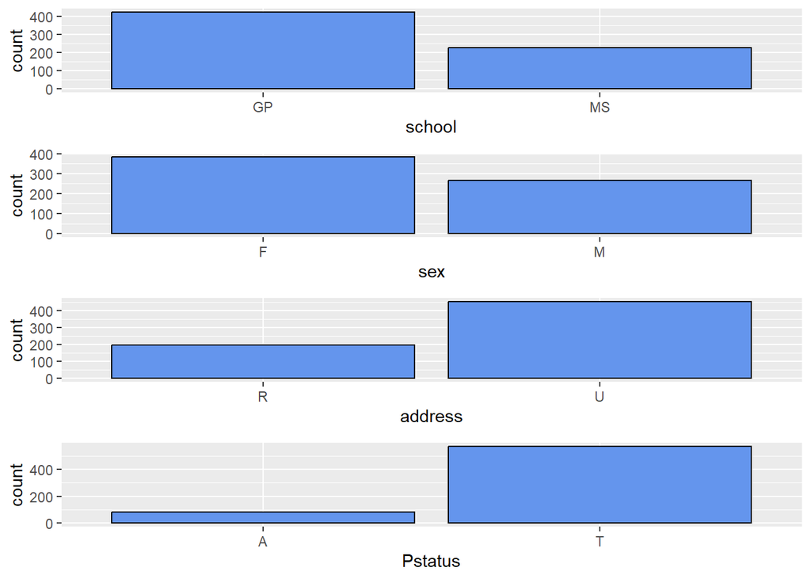

```r
histList<- list()

n = c("school","sex","address","Pstatus")
studentsDataAux= studentsData %>% select(all_of(n))
for(i in 1:ncol(studentsDataAux)){
  col <- names(studentsDataAux)[i]
  ggp <- ggplot(studentsDataAux, aes_string(x = col)) +
    geom_histogram(stat = "count",bins = 30, fill = "cornflowerblue", color = "black",ggtittle = "Comptador")
      histList[[i]] <- ggp
}
 multiplot(plotlist = histList, cols = 1)
```

**Observacions**:

- Hi ha més alumnes de l’escola GP que MS
- Hi ha mes noies que nois
- La gran majoria d’alumnes viuen en entorns urbans
- La gran majoria de pares viuen junts

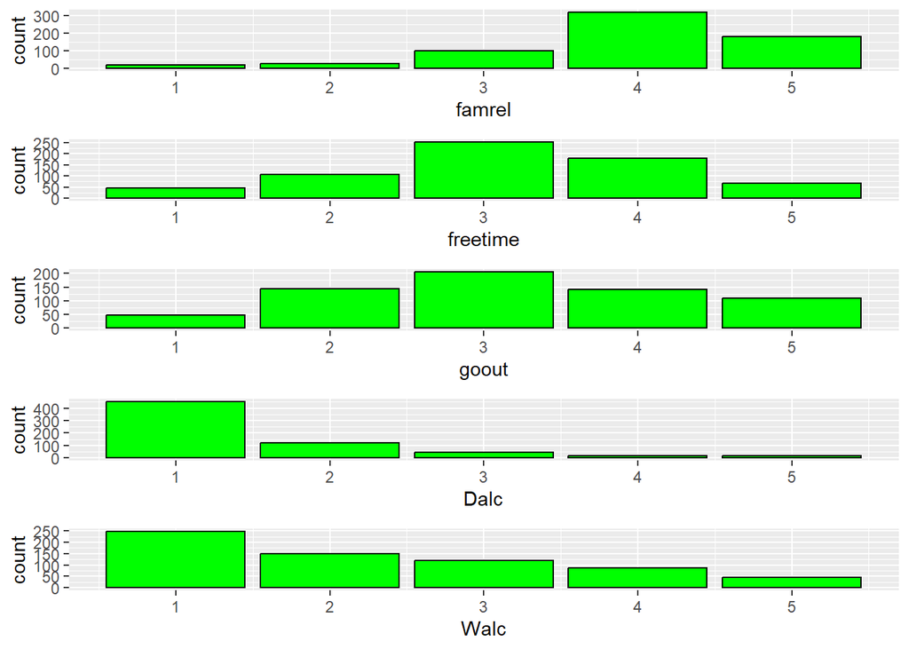

```r
histList<- list()

n = c("famrel","freetime","goout","Dalc","Walc")
studentsDataAux= studentsData %>% select(all_of(n))
for(i in 1:ncol(studentsDataAux)){
  col <- names(studentsDataAux)[i]
  ggp <- ggplot(studentsDataAux, aes_string(x = col)) +
    geom_histogram(stat = "count",bins = 30, fill = "green", color = "black",ggtittle = "Comptador")
      histList[[i]] <- ggp
}
 multiplot(plotlist = histList, cols = 1)
```

**Observacions**:

- Bona relació familiar en general
- Consum d’alcohol augmenta considerablement el cap de setmana

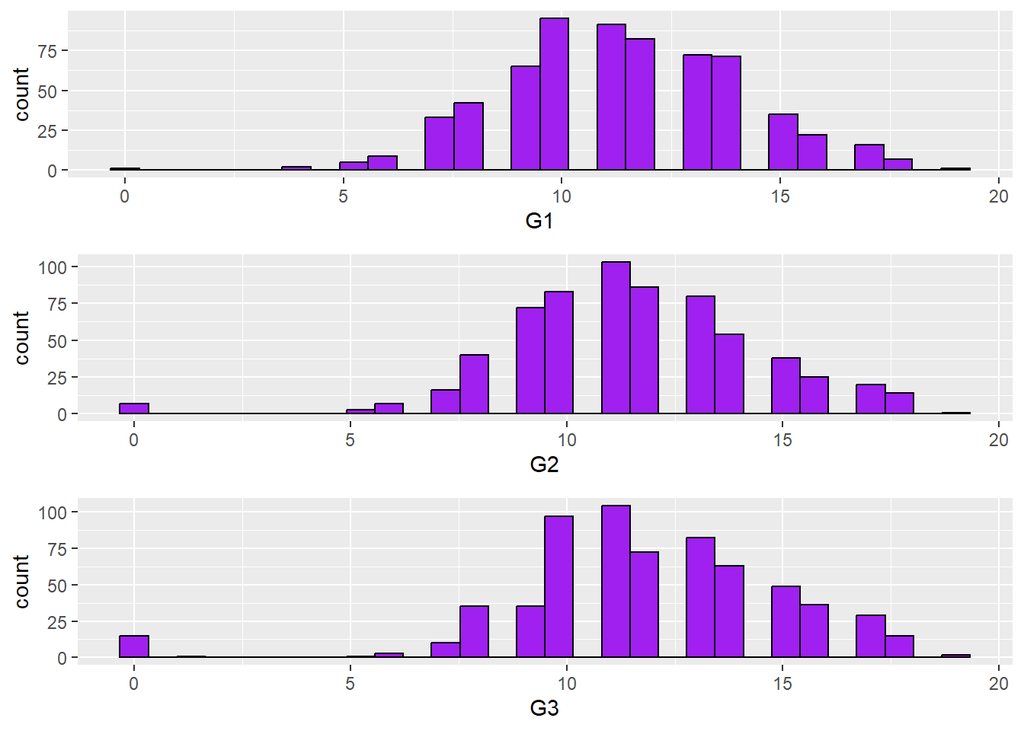

```r
histList<- list()

n = c("G1","G2", "G3")
studentsDataAux= studentsData %>% select(all_of(n))
for(i in 1:ncol(studentsDataAux)){
  col <- names(studentsDataAux)[i]
  ggp <- ggplot(studentsDataAux, aes_string(x = col)) +
    geom_histogram(bins = 30, fill = "purple", color = "black",ggtittle = "Comptador")
      histList[[i]] <- ggp
}
 multiplot(plotlist = histList, cols = 1)
```

**Observacions**:

- Hi ha més 0s al G3
- El gràfic es molt semblant en les tres variables

## 3.4 Correlació entre variables

A continuació mostrem la correlació entre les variables numèriques del joc de dades.

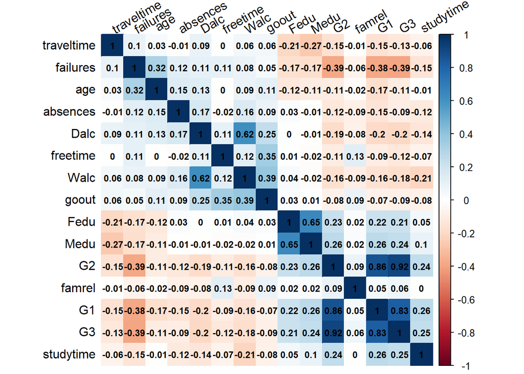

```r
if(!require("corrplot")) install.packages("corrplot"); library("corrplot")

n = c("age","Medu","Fedu","traveltime","studytime","failures","famrel","freetime","goout","Dalc","Walc","absences","G1","G2","G3")
factors= studentsData %>% select(all_of(n))
res<-cor(factors)
corrplot(res,method="color",tl.col="black", tl.srt=30, order = "AOE",
   number.cex=0.75,sig.level = 0.01, addCoef.col = "black")
```

**Observem un alt grau de correlació entre:**

- age - failures
- Walc - Dalc
- freetime - goout
- goout - Walc
- Medu - Fedu
- G1 - G2 - G3
- G1, G2 i G3 correlació negativa amb failures

# 4 Neteja

En aquest apartat processarem les dades per eliminar les que siguin errònies i redundants

El primer pas serà veure si tenim valors nuls al nostre joc de dades

```r
colSums(is.na(studentsData))
```

```
##     school        sex        age    address    Pstatus       Medu       Fedu
##          0          0          0          0          0          0          0
## traveltime  studytime   failures  schoolsup     famsup       paid activities
##          0          0          0          0          0          0          0
##     higher   romantic     famrel   freetime      goout       Dalc       Walc
##          0          0          0          0          0          0          0
##   absences         G1         G2         G3
##          0          0          0          0
```

Com podem veure, no tenim cap valor nul a cap de les columnes seleccionades. A continuació, fem la mateixa comprovació amb els valors buits

```r
colSums(studentsData=="")
```

```
##     school        sex        age    address    Pstatus       Medu       Fedu
##          0          0          0          0          0          0          0
## traveltime  studytime   failures  schoolsup     famsup       paid activities
##          0          0          0          0          0          0          0
##     higher   romantic     famrel   freetime      goout       Dalc       Walc
##          0          0          0          0          0          0          0
##   absences         G1         G2         G3
##          0          0          0          0
```

Tampoc hi ha cap valor buit a cap de les columnes.

Executem una funció per identificar tuples duplicades

```r
library(tidyverse)
```

```r
studentsData[duplicated(studentsData)]
```

```
## data frame with 0 columns and 649 rows
```

Tampoc tenim cap tupla duplicada.

El joc de dades s’ha publicat sense valors nuls, absents o instàncies repetides. Això pot resultar de gran ajuda per tots aquells que el vulguin utilitzar per a dur a terme mineria de dades, com és el nostre cas.

# 5 Discretització

En aquest apartat transformarem les dades per a que es pugui divir el valor d’un atribut numèric en 2 o més valors diferents. Al joc de dades tenim moltes variables categòriques, pero l’enunciat requereix d’un exemple de procés de discretització. Més concretament, discretitzarem la variable numèrica **absences**.

Ho farem mitjançant el mètode *discretize* de la llibreria *arules*.

```r
summary(studentsData[,"absences"])
```

```
##    Min. 1st Qu.  Median    Mean 3rd Qu.    Max.
##   0.000   0.000   2.000   3.659   6.000  32.000
```

```r
library(arules)
```

```r
studentsData['absencesIntervals'] <- discretize(studentsData$absences, method="interval", categories = 4, labels = NULL, ordered=FALSE, onlycuts=FALSE)
```

Hem dividit el nombre continu d’absències en 4 grups d’intervals. També hem decidit deixar-ho en intervals i no assignar un nom, ja que m’ha semblat més representatiu. Observe’m-ho mitjançant un gràfic.

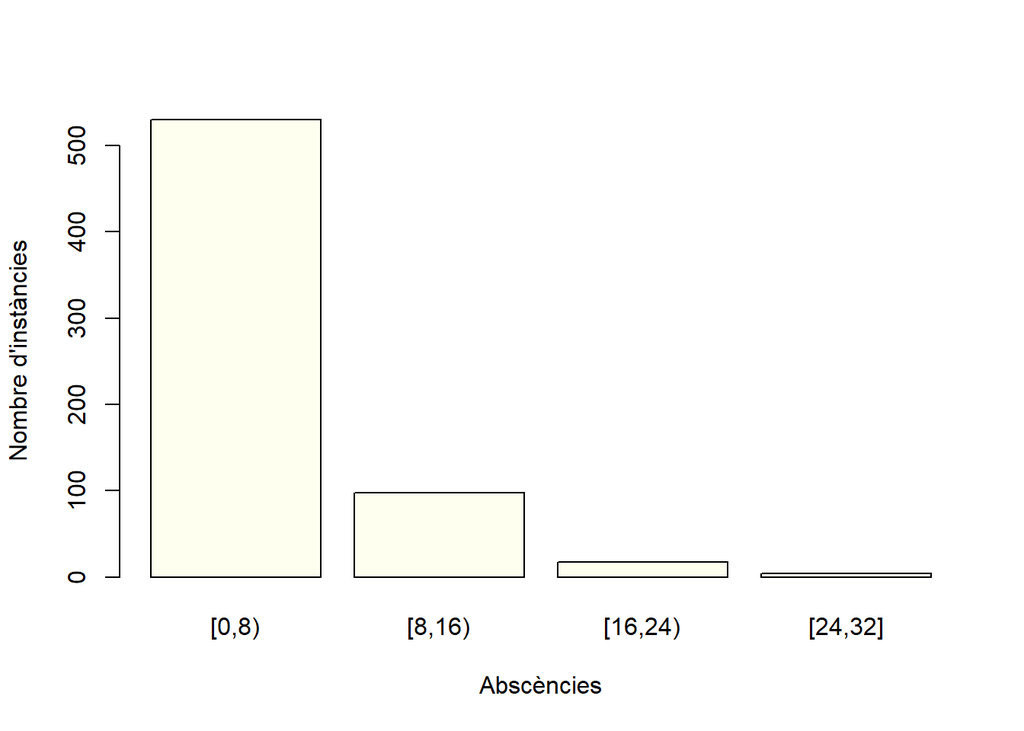

```r
plot(studentsData$absencesIntervals, xlab="Abscències", ylab="Nombre d'instàncies", col = "ivory")
```

Veiem com la gran majoria dels estudiants formen part del primer interval. Per curiositat, comptem quans formen part de l’últim interval.

```r
table(studentsData$absencesIntervals)
```

```
##
##   [0,8)  [8,16) [16,24) [24,32]
##     530      98      17       4
```

Veiem com només hi ha cuatre estudiants que hagin faltat de 24 a 32 vegades.

# 6 Reducció de dimensions (PCA)

L’anàlisi de components principals (PCA) és una tècnica que ens permetrà treballar amb noves característiques anomenades components, independents entre si. A la pràctica, el que farem serà afegir al joc de dades original aquests nous components principals que recullin una variabilitat més alta.

Aquests nous components podran substituir altres variables menys importants i que no aportin gaire valor a la predicció de la qualificaió dels estudiants.

A continuació, escalarem les dades numèricques i hi aplicarem l’anàlisi de components principals:

```r
n = c("age","Medu","Fedu","traveltime","studytime","failures","famrel","freetime","goout","Dalc","Walc","absences","G1","G2","G3")
studentsDataNumeric = studentsData %>% select(all_of(n))
stu_scale <- scale(studentsDataNumeric)
pca.stu <- prcomp(stu_scale)
summary(pca.stu)
```

```
## Importance of components:
##                           PC1    PC2     PC3     PC4     PC5     PC6     PC7
## Standard deviation     1.9125 1.3919 1.19321 1.13373 1.06610 0.96486 0.92799
## Proportion of Variance 0.2439 0.1292 0.09492 0.08569 0.07577 0.06206 0.05741
## Cumulative Proportion  0.2439 0.3730 0.46793 0.55362 0.62939 0.69145 0.74886
##                            PC8     PC9    PC10    PC11    PC12    PC13    PC14
## Standard deviation     0.90698 0.89876 0.80275 0.74516 0.60719 0.56457 0.41848
## Proportion of Variance 0.05484 0.05385 0.04296 0.03702 0.02458 0.02125 0.01167
## Cumulative Proportion  0.80370 0.85756 0.90052 0.93753 0.96211 0.98336 0.99504
##                           PC15
## Standard deviation     0.27288
## Proportion of Variance 0.00496
## Cumulative Proportion  1.00000
```

L’histograma següent mostra de forma visual el pes de cada dimensió sobre el total de dades.

```r
if (!require('factoextra')) install.packages('factoextra'); library('factoextra')
#Els valors propis corresponen a la quantitat de variació explicada per cada component principal (PC).
ev= get_eig(pca.stu)
ev
```

```
##        eigenvalue variance.percent cumulative.variance.percent
## Dim.1   3.6577603       24.3850688                    24.38507
## Dim.2   1.9374021       12.9160138                    37.30108
## Dim.3   1.4237538        9.4916919                    46.79277
## Dim.4   1.2853493        8.5689951                    55.36177
## Dim.5   1.1365617        7.5770781                    62.93885
## Dim.6   0.9309528        6.2063517                    69.14520
## Dim.7   0.8611650        5.7411001                    74.88630
## Dim.8   0.8226151        5.4841006                    80.37040
## Dim.9   0.8077712        5.3851415                    85.75554
## Dim.10  0.6443997        4.2959978                    90.05154
## Dim.11  0.5552689        3.7017928                    93.75333
## Dim.12  0.3686754        2.4578359                    96.21117
## Dim.13  0.3187398        2.1249317                    98.33610
## Dim.14  0.1751221        1.1674809                    99.50358
## Dim.15  0.0744629        0.4964193                   100.00000
```

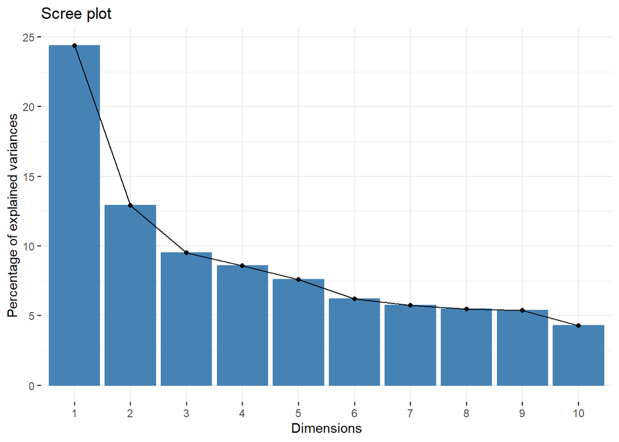

```r
fviz_eig(pca.stu)
```

Farem servir el mètode de Kaiser per escollir les característiques. Aquest mètode es quedarà amb totes les dimensions amb variància superior a 1.

```r
var_stu_scale <- pca.stu$sdev^2
head(var_stu_scale)
```

```
## [1] 3.6577603 1.9374021 1.4237538 1.2853493 1.1365617 0.9309528
```

```r
pca_var <- get_pca_var(pca.stu)
pca_var
```

```
## Principal Component Analysis Results for variables
##  ===================================================
##   Name       Description
## 1 "$coord"   "Coordinates for the variables"
## 2 "$cor"     "Correlations between variables and dimensions"
## 3 "$cos2"    "Cos2 for the variables"
## 4 "$contrib" "contributions of the variables"
```

## 6.1 Contribució

```r
pca_var <- get_pca_var(pca.stu)
pca_var
```

```
## Principal Component Analysis Results for variables
##  ===================================================
##   Name       Description
## 1 "$coord"   "Coordinates for the variables"
## 2 "$cor"     "Correlations between variables and dimensions"
## 3 "$cos2"    "Cos2 for the variables"
## 4 "$contrib" "contributions of the variables"
```

A continuació, observem la contribució de cadascuna de les variables originals numèriques als components principals. Aquelles que no contribueixin a la variablitat de les primeres 5 dimensions es podran eliminar per simplificar l’anàlisi i **reduir la dimensionalitat**.

```r
library(corrplot)
head(pca_var$contrib[,1:5],15)
```

```
##                 Dim.1       Dim.2      Dim.3       Dim.4       Dim.5
## age         2.2730020  0.15009719  1.7877580  8.25432997 45.33195939
## Medu        5.2619420 11.53435038 23.1356138  0.25237651  0.60343937
## Fedu        4.0883179 13.29898818 22.6975983  0.32115341  0.09406767
## traveltime  2.0804774  1.43079280 12.5872520  0.10086598  4.96907379
## studytime   3.9257141  1.13841757  0.3099603  0.08383409  4.92495202
## failures    8.2870623  0.34925469  0.3814260  0.66885405 19.91868393
## famrel      0.2919783  0.01218525  1.4844367 27.96109016  4.58515655
## freetime    1.0584344  5.36179859  2.4659454 29.13743471  3.40216863
## goout       1.4718861 17.35789181  8.0065179  7.08698423  1.60355962
## Dalc        4.2364958 19.12326119  2.5816056  5.02678006  3.42057440
## Walc        3.8300960 24.46543477  3.6281179  2.80050961  5.25772296
## absences    1.4531895  3.29105767  0.6098080 14.35258746  4.23755311
## G1         20.2173667  0.84222673  6.0317977  0.80666136  0.10131713
## G2         21.0539336  0.98807058  7.0703886  1.25060467  0.83899691
## G3         20.4701039  0.65617259  7.2217737  1.89593374  0.71077449
```

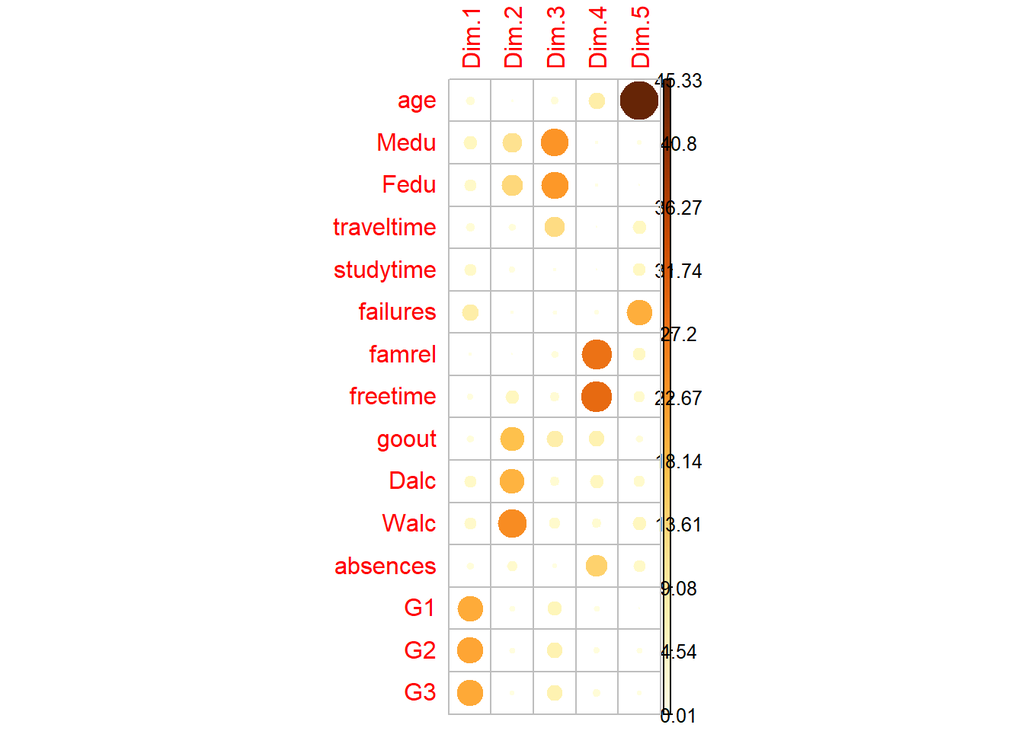

```r
corrplot(pca_var$contrib[,1:5], is.corr=FALSE)
```

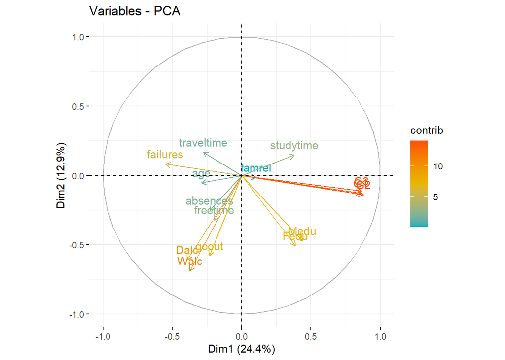

```r
fviz_pca_var(pca.stu, col.var = "contrib",
             gradient.cols = c("#00AFBB", "#E7B800", "#FC4E07")
             )
```

```r
componentes_principales <- pca.stu$x[, 1:5]
variables_no_contributives <- c("studytime", "traveltime", "absences")

studentsData <- studentsData[, !(names(studentsData) %in% variables_no_contributives)]

datos_con_pca <- cbind(studentsData, componentes_principales)
structure = str(datos_con_pca)
```

```
## 'data.frame':    649 obs. of  28 variables:
##  $ school           : chr  "GP" "GP" "GP" "GP" ...
##  $ sex              : chr  "F" "F" "F" "F" ...
##  $ age              : int  18 17 15 15 16 16 16 17 15 15 ...
##  $ address          : chr  "U" "U" "U" "U" ...
##  $ Pstatus          : chr  "A" "T" "T" "T" ...
##  $ Medu             : int  4 1 1 4 3 4 2 4 3 3 ...
##  $ Fedu             : int  4 1 1 2 3 3 2 4 2 4 ...
##  $ failures         : int  0 0 0 0 0 0 0 0 0 0 ...
##  $ schoolsup        : chr  "yes" "no" "yes" "no" ...
##  $ famsup           : chr  "no" "yes" "no" "yes" ...
##  $ paid             : chr  "no" "no" "no" "no" ...
##  $ activities       : chr  "no" "no" "no" "yes" ...
##  $ higher           : chr  "yes" "yes" "yes" "yes" ...
##  $ romantic         : chr  "no" "no" "no" "yes" ...
```

[output cut: 16 more lines]

# 7 Conclusions

En aquesta primera part del projecte de mineria de dades, hem presentat l’objectiu analític i el joc de dades seleccionat. Hem dut a terme una exploració inicialde les dades, on hem descrit cadascún dels atributs, hem visualitzat hisogrames i la correlació de les variables entre elles. A l’apartat de neteja hem busca valors nuls o absents, però no n’hem trobat cap. Això indica que l’autor de les dades ha tingut cura de preparar-les adequadament abans de la seva publicació, assegurant-ne la qualitat.

# 8 Bibliografia

1. Cortez,Paulo. (2014). *Student Performance*. UCI Machine Learning Repository. https://doi.org/10.24432/C5TG7T. https://archive.ics.uci.edu/
2. Abouelela. (2018). *Identify and Remove Duplicate Data in R - Datanovia.* Datanovia. https://www.datanovia.com/en/lessons/identify-and-remove-duplicate-data-in-r/
3. Study in europe. (n.d.). *The Portuguese grading system.* https://www.studyineurope.eu/study-in-portugal/grades
4. *discretize function - RDocumentation.* (n.d.). https://www.rdocumentation.org/packages/arules/versions/1.5-0/topics/discretize
5. Zach. (2021). *How to count number of occurrences in columns in R.* Statology. https://www.statology.org/r-count-number-of-occurrences-in-column/